# 12 Mineral deposits

In the mining industry, resource estimation consists of interpolating measurements of metal and mineral grades from drill hole samples to 3D grids known as “block models”. Due to highly skewed distributions, several pre-processing steps need to be performed before the actual interpolation. In this chapter, we will cover simple steps for resource estimation and economic assessment of a real mineral deposit.

**TOOLS COVERED:** `@groupby`, `@transform`, `@combine`, `CLR`, `ProjectionPursuit`, `Kriging`, `Interpolate`, `InterpolateNeighbors`, `Shadow`, `Map`, `Filter`, `variogram`, `boundingbox`, `convexhull`, `viewer`

**MODULES:**

```julia
# framework
using GeoStats

# IO modules
using GeoIO

# viz modules
using PairPlots
import CairoMakie as Mke
```

**Note**

Although we use CairoMakie.jl in this book, many of the 3D visualizations in this chapter demand a more performant Makie.jl backend. Consider using GLMakie.jl if you plan to reproduce the code locally.

## 12.1 Data

The [GeoMet](https://zenodo.org/record/7051975) dataset (Hoffimann, Augusto, Resende, Mathias, Mazzinghy, Bianchetti, Mendes, Souza, Andrade, Tarcísio Domingues, et al. 2022) consists of three geospatial tables stored as CSV files. In this chapter, we will only use the **drillholes.csv** table.

Drill hole samples are always available in mining projects. They contain chemical information for each rock sample (a cylinder) along the drill hole trajectories. In this case, the data has been processed, and only the `Cartesian` “X”, “Y”, “Z” coordinates of the centroids of the cylinders were stored:

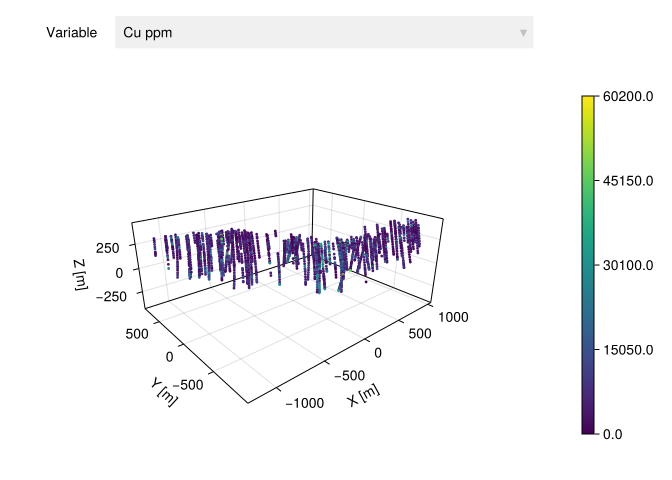

```julia
url = "https://zenodo.org/record/7051975/files/drillholes.csv?download=1"

csv = download(url, tempname()*".csv")

dtable = GeoIO.load(csv, coords = ("X", "Y", "Z"))

dtable |> Select("Cu ppm") |> viewer
```

```julia
dtable |> describe
```

```
Table with 7 columns and 19 rows:
      variable  scitype      mean      minimum  median    maximum   nmissing
    ┌───────────────────────────────────────────────────────────────────────
 1  │ HOLEID    Categorical  nothing   1        nothing   119       0
 2  │ Ag ppm    Continuous   1.86199   0.01     1.14      15.38     0
 3  │ Al ppm    Continuous   52374.8   2400.0   56100.0   103300.0  0
 4  │ Au ppm    Continuous   0.470965  0.0      0.21      5.89      0
 5  │ C ppm     Continuous   1117.7    100.0    700.0     20700.0   0
 6  │ Ca ppm    Continuous   9900.6    100.0    6400.0    73700.0   0
 7  │ Cl ppm    Continuous   2303.75   5.48     1756.23   14273.8   0
 8  │ Cu ppm    Continuous   7540.4    0.0      5000.0    60200.0   0
 9  │ F ppm     Continuous   2528.58   20.89    1610.47   19786.3   0
 10 │ Fe ppm    Continuous   245452.0  9900.0   246000.0  500000.0  0
 11 │ K ppm     Continuous   13610.9   100.0    12450.0   45500.0   0
 12 │ Mg ppm    Continuous   17673.0   200.0    14000.0   88800.0   0
 13 │ Mn ppm    Continuous   4282.96   88.95    3685.35   24812.8   0
 14 │ Na ppm    Continuous   4404.8    100.0    1400.0    58900.0   0
 15 │ P ppm     Continuous   720.896   38.08    630.705   5576.14   0
 16 │ Pb ppm    Continuous   9.3938    0.8      6.005     247.83    0
 17 │ S ppm     Continuous   2712.95   100.0    1700.0    21500.0   0
 ⋮  │    ⋮           ⋮          ⋮         ⋮        ⋮         ⋮         ⋮
```

There are 18 chemical elements in the table, all measured in parts per million (ppm). The table also stores an integer identifier for each hole trajectory in the “HOLEID” column. There are 119 such trajectories as shown in the “maximum” column of the `describe` output.

**Note**

In most mining projects, the drill hole samples are available as “SURVEY”, “COLLAR” and “INTERVAL” tables, which can be desurveyed and composited with DrillHoles.jl.

## 12.2 Objectives

Our main objective is to estimate the economic value associated with each mining block in a 3D block model, i.e. a `CartesianGrid` with `Hexahedron` geometries (the blocks). This economic value in U$ dollars is estimated in terms of various other geospatial variables:

$$Value = \underbrace{V \times \rho \times Cu \times f \times P}_{\text{revenue}} - \underbrace{V \times \rho \times (C_m + C_p)}_{\text{cost}}$$

where

- $V$ is the volume of the block in $m^3$
- $\rho$ is the rock density in $ton/m^3$
- $Cu$ is the grade of copper in $[0,1]$
- $f$ is the recovery of copper in $[0,1]$
- $P$ is the selling price in $U\$/ton$
- $C_m$ is the mining cost in $U\$/ton$
- $C_p$ is the plant cost in $U\$/ton$

Secondary objectives include the localization (through 3D visualization) of blocks with high economic value, high grades of Au and Ag, and low grade of S.

For simplicity, we assume the following constants:

- $\rho = 2.75\ ton / m^3$
- $P = 4000\ U\$ / ton$
- $C_m = 4\ U\$ / ton$
- $C_p = 10\ U\$ / ton$

## 12.3 Methodology

In order to estimate the economic value of each mining block, we need to interpolate the grade of Cu. Because we also want to localize the blocks with high grades of Au and Ag, and low grade of S, we will perform *multivariate* geostatistical interpolation of Cu, Au, Ag and S.

The proposed methodology has the following steps:

1. Preliminary analysis and processing
2. Definition of interpolation domain
3. Multivariate geostatistical interpolation
4. Economic assessment and visualizations

### 12.3.1 Preliminary analysis

We recommend to start any application discarding all information that is not relevant for the stated objectives. In this case, the geotable contains measurements of various chemical elements that are not used in the economic assessment. We define a **cleaning pipeline** that selects and renames columns of interest, and adds units to the measurements:

```julia
selectholeid = Select("HOLEID")

selectgrades = Select("Cu ppm" => "Cu",
                      "Au ppm" => "Au",
                      "Ag ppm" => "Ag",
                      "S ppm"  => "S") →
               Functional(x -> 1e-4*x*u"percent") # 1 ppm = 1e-4 percent

dclean = selectholeid ⊔ selectgrades
```

```
ParallelTableTransform
├─ Select(selector: [:HOLEID], newnames: nothing)
└─ SequentialTransform
   ├─ Select(selector: [Symbol("Cu ppm"), Symbol("Au ppm"), Symbol("Ag ppm"), Symbol("S ppm")], newnames: [:Cu, :Au, :Ag, :S])
   └─ Functional(selector: all, fun: #2)
```

```julia
dtable = dclean(dtable)
```

1990 rows omitted

| 2000×6 GeoTable over 2000 PointSet HOLEID Categorical [NoUnits] | 2000×6 GeoTable over 2000 PointSet Cu Continuous [%] | 2000×6 GeoTable over 2000 PointSet Au Continuous [%] | 2000×6 GeoTable over 2000 PointSet Ag Continuous [%] | 2000×6 GeoTable over 2000 PointSet S Continuous [%] | 2000×6 GeoTable over 2000 PointSet geometry Point 🖈 Cartesian{NoDatum} |
| --- | --- | --- | --- | --- | --- |
| 1 | 0.72 % | 0.000104 % | 6.4e-5 % | 0.61 % | (x: 559.725 m, y: -513.31 m, z: 252.82 m) |
| 1 | 0.1 % | 6.0e-6 % | 2.0e-5 % | 0.06 % | (x: 558.955 m, y: -515.23 m, z: 246.87 m) |
| 1 | 2.18 % | 0.000202 % | 0.000344 % | 1.17 % | (x: 557.225 m, y: -519.61 m, z: 233.37 m) |
| 1 | 2.29 % | 0.000343 % | 0.000488 % | 1.1 % | (x: 555.375 m, y: -524.3 m, z: 218.92 m) |
| 1 | 0.59 % | 5.0e-5 % | 0.000125 % | 0.22 % | (x: 553.825 m, y: -528.21 m, z: 206.94 m) |
| 1 | 0.56 % | 9.0e-5 % | 9.0e-5 % | 0.28 % | (x: 552.075 m, y: -532.56 m, z: 193.91 m) |
| 1 | 2.0 % | 0.000356 % | 9.3e-5 % | 1.96 % | (x: 550.305 m, y: -537.08 m, z: 180.8 m) |
| 1 | 0.28 % | 2.1e-5 % | 7.6e-5 % | 0.14 % | (x: 547.495 m, y: -544.31 m, z: 160.08 m) |
| 1 | 0.61 % | 2.0e-5 % | 0.000112 % | 0.28 % | (x: 544.335 m, y: -552.43 m, z: 137.08 m) |
| 1 | 0.25 % | 1.6e-5 % | 7.7e-5 % | 0.09 % | (x: 541.695 m, y: -559.19 m, z: 117.96 m) |
| ⋮ | ⋮ | ⋮ | ⋮ | ⋮ | ⋮ |

In order to better understand the multivariate distribution of chemical elements, we visualize the `values` of the drill hole samples with the `pairplot`:

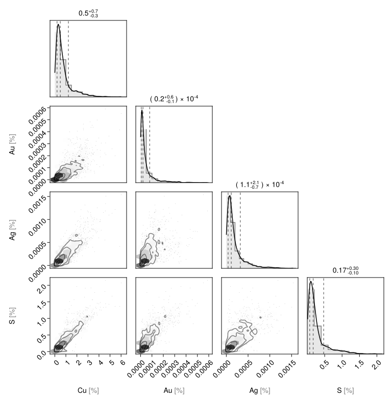

```julia
dtable |> Select("Cu", "Au", "Ag", "S") |> values |> pairplot
```

We can observe that the distribution is very skewed.

### 12.3.2 Domain of interpolation

Before we can interpolate these variables, we need to define our domain of interpolation. In this application, we will define a 3D `CartesianGrid` in terms of the drill hole trajectories alone. Some of the `Hexahedron` geometries will be disabled whenever they are outside the `convexhull` of the points.

First, let’s create our full `CartesianGrid` using the `boundingbox` of the trajectories:

```julia
# compute bounding box
bbox = boundingbox(dtable.geometry)

# size of blocks in meters
bsize = (25.0u"m", 25.0u"m", 12.5u"m")

# define Cartesian grid
grid = CartesianGrid(extrema(bbox)..., bsize)
```

```
85×66×66 CartesianGrid
├─ minimum: Point(x: -1150.004825000069 m, y: -882.9003199972212 m, z: -399.92 m)
├─ maximum: Point(x: 974.9951749999309 m, y: 767.0996800027788 m, z: 425.08 m)
└─ spacing: (25.0 m, 25.0 m, 12.5 m)
```

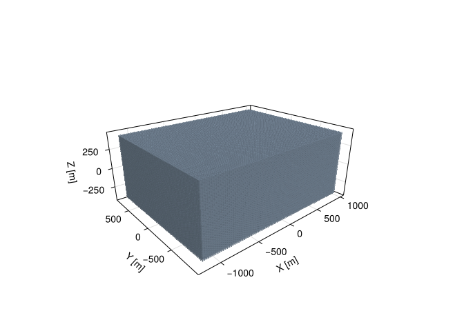

```julia
viz(dtable.geometry, color = "black")
viz!(grid, alpha = 0.2)
Mke.current_figure()
```

Second, let’s compute the `convexhull` of the `Shadow` of all points on the xy plane:

```julia
shadow(point) = point |> Shadow("xy")

points = shadow.(dtable.geometry)

chull = convexhull(points)
```

```
Pgon
├─ Point(x: -1150.004825000069 m, y: 641.2296800035983 m)
├─ Point(x: -1093.1548250000924 m, y: 499.8996800035238 m)
├─ Point(x: 299.96517499990296 m, y: -607.6803199965507 m)
├─ Point(x: 725.185174999875 m, y: -875.7303199972957 m)
├─ Point(x: 835.2351749999216 m, y: -882.9003199972212 m)
⋮
├─ Point(x: 384.0951749999076 m, y: 146.5496800020337 m)
├─ Point(x: 230.06517499987967 m, y: 301.6596800033003 m)
├─ Point(x: -312.6848250001203 m, y: 560.3596800025553 m)
├─ Point(x: -880.6048250000458 m, y: 756.5096800029278 m)
└─ Point(x: -1120.564825000125 m, y: 701.2196800019592 m)
```

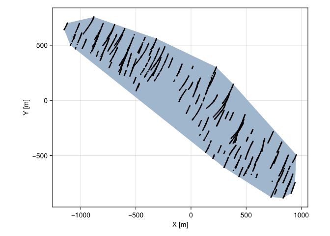

```julia
viz(chull)
viz!(points, color = "black")
Mke.current_figure()
```

We can filter the grid to retain `Hexahedron`s for which the projected centroid is inside the `convexhull`:

```julia
active = findall(h -> shadow(centroid(h)) ∈ chull, grid)

blocks = view(grid, active)
```

```
136422 view(::CartesianGrid, [76, 77, 78, 79, ..., 370102, 370103, 370104, 370186])
├─ Hexahedron((x: 724.995 m, y: -882.9 m, z: -399.92 m), ..., (x: 724.995 m, y: -857.9 m, z: -387.42 m))
├─ Hexahedron((x: 749.995 m, y: -882.9 m, z: -399.92 m), ..., (x: 749.995 m, y: -857.9 m, z: -387.42 m))
├─ Hexahedron((x: 774.995 m, y: -882.9 m, z: -399.92 m), ..., (x: 774.995 m, y: -857.9 m, z: -387.42 m))
├─ Hexahedron((x: 799.995 m, y: -882.9 m, z: -399.92 m), ..., (x: 799.995 m, y: -857.9 m, z: -387.42 m))
├─ Hexahedron((x: 824.995 m, y: -882.9 m, z: -399.92 m), ..., (x: 824.995 m, y: -857.9 m, z: -387.42 m))
⋮
├─ Hexahedron((x: -900.005 m, y: 717.1 m, z: 412.58 m), ..., (x: -900.005 m, y: 742.1 m, z: 425.08 m))
├─ Hexahedron((x: -875.005 m, y: 717.1 m, z: 412.58 m), ..., (x: -875.005 m, y: 742.1 m, z: 425.08 m))
├─ Hexahedron((x: -850.005 m, y: 717.1 m, z: 412.58 m), ..., (x: -850.005 m, y: 742.1 m, z: 425.08 m))
├─ Hexahedron((x: -825.005 m, y: 717.1 m, z: 412.58 m), ..., (x: -825.005 m, y: 742.1 m, z: 425.08 m))
└─ Hexahedron((x: -900.005 m, y: 742.1 m, z: 412.58 m), ..., (x: -900.005 m, y: 767.1 m, z: 425.08 m))
```

We would also like to filter `Hexahedron`s that are above the terrain. Let’s create a simple terrain elevation model by interpolating the vertical `z` coordinate of the first point of each trajectory:

```julia
zcoord(point) = coords(point).z

ztable = @chain dtable begin
  @groupby(:HOLEID)
  @transform(:z = zcoord(:geometry), :geometry = shadow(:geometry))
  @combine(:z = first(:z), :geometry = first(:geometry))
end
```

109 rows omitted

| 119×3 GeoTable over 119 PointSet HOLEID Categorical [NoUnits] | 119×3 GeoTable over 119 PointSet z Continuous [m] | 119×3 GeoTable over 119 PointSet geometry Point 🖈 Cartesian{NoDatum} |
| --- | --- | --- |
| 1 | 252.82 m | (x: 559.725 m, y: -513.31 m) |
| 2 | 280.94 m | (x: 745.345 m, y: -280.6 m) |
| 3 | 281.09 m | (x: -304.025 m, y: 318.13 m) |
| 4 | 256.16 m | (x: -416.575 m, y: 570.35 m) |
| 5 | 324.65 m | (x: 198.815 m, y: -524.78 m) |
| 6 | 317.1 m | (x: 493.605 m, y: -530.83 m) |
| 7 | 245.13 m | (x: -367.965 m, y: 394.78 m) |
| 8 | 250.67 m | (x: 17.6752 m, y: 33.4297 m) |
| 9 | 254.49 m | (x: -514.305 m, y: 594.68 m) |
| 10 | 294.44 m | (x: -674.415 m, y: 596.84 m) |
| ⋮ | ⋮ | ⋮ |

We perform the interpolation of the `z` coordinate on the projected centroids of the blocks:

```julia
centroids = unique(shadow.(centroid.(blocks)))

ztable = ztable |> Select("z") |> Interpolate(centroids, model=IDW())
```

2057 rows omitted

| 2067×2 GeoTable over 2067 PointSet z Continuous [m] | 2067×2 GeoTable over 2067 PointSet geometry Point 🖈 Cartesian{NoDatum} |
| --- | --- |
| 315.273 m | (x: 737.495 m, y: -870.4 m) |
| 318.783 m | (x: 762.495 m, y: -870.4 m) |
| 321.816 m | (x: 787.495 m, y: -870.4 m) |
| 324.655 m | (x: 812.495 m, y: -870.4 m) |
| 327.816 m | (x: 837.495 m, y: -870.4 m) |
| 309.922 m | (x: 687.495 m, y: -845.4 m) |
| 314.0 m | (x: 712.495 m, y: -845.4 m) |
| 318.755 m | (x: 737.495 m, y: -845.4 m) |
| 323.911 m | (x: 762.495 m, y: -845.4 m) |
| 327.361 m | (x: 787.495 m, y: -845.4 m) |
| ⋮ | ⋮ |

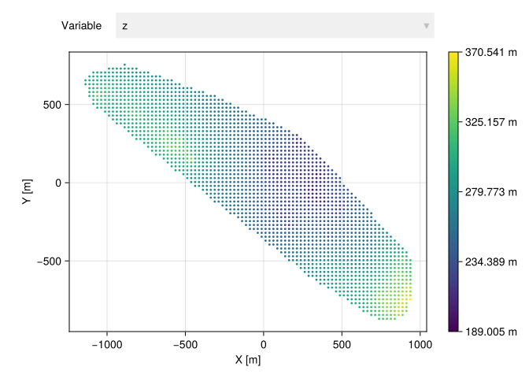

```julia
ztable |> viewer
```

Finally, we can filter the blocks for which the `z` coordinate is below the terrain:

```julia
p(h) = shadow(centroid(h))
z(h) = zcoord(centroid(h))

zdict = Dict(ztable.geometry .=> ztable.z)

active = findall(h -> z(h) < zdict[p(h)], blocks)

blocks = view(blocks, active)
```

```
110854 view(::CartesianGrid, [76, 77, 78, 79, ..., 337107, 337109, 337193, 342719])
├─ Hexahedron((x: 724.995 m, y: -882.9 m, z: -399.92 m), ..., (x: 724.995 m, y: -857.9 m, z: -387.42 m))
├─ Hexahedron((x: 749.995 m, y: -882.9 m, z: -399.92 m), ..., (x: 749.995 m, y: -857.9 m, z: -387.42 m))
├─ Hexahedron((x: 774.995 m, y: -882.9 m, z: -399.92 m), ..., (x: 774.995 m, y: -857.9 m, z: -387.42 m))
├─ Hexahedron((x: 799.995 m, y: -882.9 m, z: -399.92 m), ..., (x: 799.995 m, y: -857.9 m, z: -387.42 m))
├─ Hexahedron((x: 824.995 m, y: -882.9 m, z: -399.92 m), ..., (x: 824.995 m, y: -857.9 m, z: -387.42 m))
⋮
├─ Hexahedron((x: 924.995 m, y: -682.9 m, z: 337.58 m), ..., (x: 924.995 m, y: -657.9 m, z: 350.08 m))
├─ Hexahedron((x: 874.995 m, y: -757.9 m, z: 350.08 m), ..., (x: 874.995 m, y: -732.9 m, z: 362.58 m))
├─ Hexahedron((x: 924.995 m, y: -757.9 m, z: 350.08 m), ..., (x: 924.995 m, y: -732.9 m, z: 362.58 m))
├─ Hexahedron((x: 899.995 m, y: -732.9 m, z: 350.08 m), ..., (x: 899.995 m, y: -707.9 m, z: 362.58 m))
└─ Hexahedron((x: 924.995 m, y: -757.9 m, z: 362.58 m), ..., (x: 924.995 m, y: -732.9 m, z: 375.08 m))
```

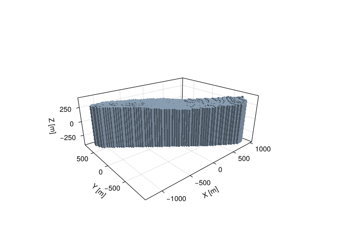

```julia
viz(blocks)
```

The filtered blocks constitute our domain of interpolation.

### 12.3.3 Interpolation of grades

We saw that the distribution of chemical elements in the drill hole samples is very skewed. This is always the case in the mining industry. Another issue is that metal and mineral grades are examples of **compositional data** (Aitchison 1982). The values in these variables are constrained to live in the interval $[0,1]$ and to sum up to 100% if all chemical elements are considered.

#### 12.3.3.1 Preprocessing

In order to remove compositional data constraints, we will perform the centered log-ratio transform (`CLR`) from the CoDa.jl module:

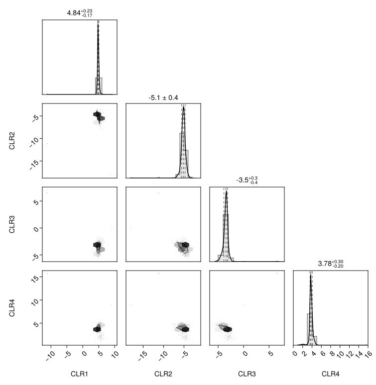

```julia
grades = dtable |> Select("Cu", "Au", "Ag", "S")

grades |> CLR() |> values |> pairplot
```

After the transform, the variables are free to vary in the unbounded interval $[-\infty,\infty]$. The theory behind this transform is beyond the scope of this book. Nevertheless, it is a simple mathematical expression in terms of logarithms of ratios (e.g., Cu/S).

Next, we attempt to transform the multivariate distribution to a multivariate standard normal using the `ProjectionPursuit` transform:

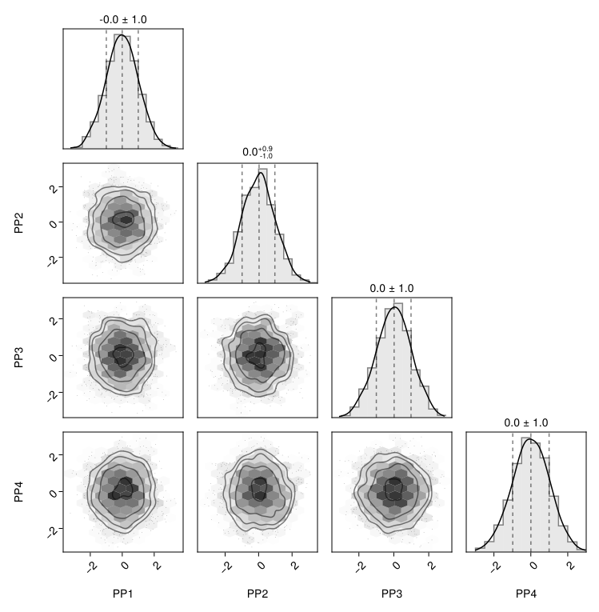

```julia
grades |> CLR() |> ProjectionPursuit() |> values |> pairplot
```

The `ProjectionPursuit` is an advanced statistical transform that removes non-linear associations between variables using an iterative procedure (Friedman 1987). The result is a set of independent variables that can be interpolated separately.

In order to “undo” these transforms after the interpolation, we create a revertible pipeline:

```julia
preproc = CLR() → ProjectionPursuit()

samples, cache = apply(preproc, grades)

samples
```

1990 rows omitted

| 2000×5 GeoTable over 2000 PointSet PP1 Continuous [NoUnits] | 2000×5 GeoTable over 2000 PointSet PP2 Continuous [NoUnits] | 2000×5 GeoTable over 2000 PointSet PP3 Continuous [NoUnits] | 2000×5 GeoTable over 2000 PointSet PP4 Continuous [NoUnits] | 2000×5 GeoTable over 2000 PointSet geometry Point 🖈 Cartesian{NoDatum} |
| --- | --- | --- | --- | --- |
| -0.813113 | 1.46731 | -1.28011 | 1.0801 | (x: 559.725 m, y: -513.31 m, z: 252.82 m) |
| -1.44823 | -0.356945 | -1.73432 | 1.0498 | (x: 558.955 m, y: -515.23 m, z: 246.87 m) |
| -0.336919 | 1.00413 | 0.309706 | 1.30045 | (x: 557.225 m, y: -519.61 m, z: 233.37 m) |
| -1.36966 | 1.47757 | 0.0989729 | -0.375058 | (x: 555.375 m, y: -524.3 m, z: 218.92 m) |
| -0.436086 | 1.0889 | -0.450009 | -0.382323 | (x: 553.825 m, y: -528.21 m, z: 206.94 m) |
| -1.02474 | 1.73027 | -0.242346 | 0.152243 | (x: 552.075 m, y: -532.56 m, z: 193.91 m) |
| -0.496114 | 1.94775 | -1.95021 | 1.39519 | (x: 550.305 m, y: -537.08 m, z: 180.8 m) |
| -1.91921 | 0.329876 | -0.21724 | 0.70227 | (x: 547.495 m, y: -544.31 m, z: 160.08 m) |
| -0.140434 | -1.26531 | -0.990132 | 1.47529 | (x: 544.335 m, y: -552.43 m, z: 137.08 m) |
| -1.38398 | -0.536083 | -0.267953 | -0.13802 | (x: 541.695 m, y: -559.19 m, z: 117.96 m) |
| ⋮ | ⋮ | ⋮ | ⋮ | ⋮ |

#### 12.3.3.2 Geospatial correlation

Let’s fit a theoretical variogram model to each (independent) variable:

```julia
maxlag = 300.0u"m"

nv = ncol(samples) - 1

gs = [variogram(samples, i, maxlag = maxlag) for i in 1:nv]

γs = [GeoStatsFunctions.fit(ExponentialVariogram, g) for g in gs]
```

```
4-element Vector{ExponentialVariogram{MetricBall{1, Quantity{Float64, 𝐋, Unitful.FreeUnits{(m,), 𝐋, nothing}}, LinearAlgebra.UniformScaling{Bool}, EuclideanDistance}, Float64}}:
 ExponentialVariogram(range: 229.269 m, sill: 0.924023, nugget: 0.40244)
 ExponentialVariogram(range: 179.899 m, sill: 0.982863, nugget: 0.585862)
 ExponentialVariogram(range: 211.022 m, sill: 0.93971, nugget: 0.505665)
 ExponentialVariogram(range: 292.568 m, sill: 0.928568, nugget: 0.446286)
```

We can plot the fitted model on top of the empirical variogram as follows:

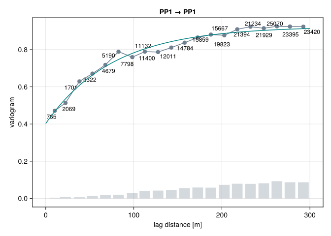

```julia
function gammaplot(g, γ)
  fig = funplot(g, maxlag = maxlag)
  funplot!(fig, γ, maxlag = maxlag)
end

gammaplot(gs[1], γs[1])
```

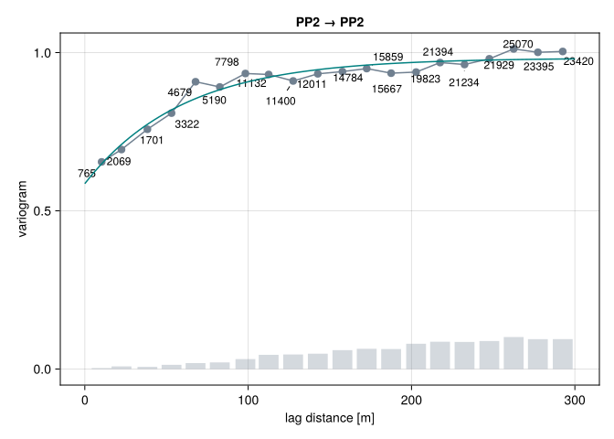

```julia
gammaplot(gs[2], γs[2])
```

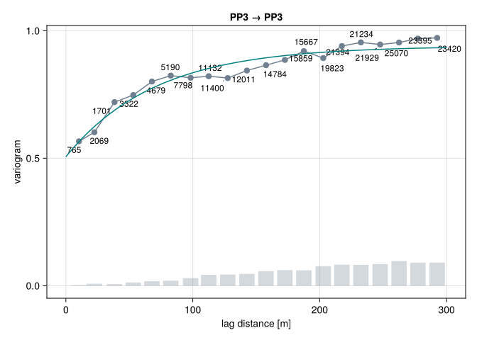

```julia
gammaplot(gs[3], γs[3])
```

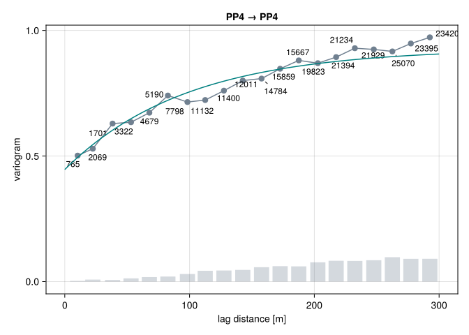

```julia
gammaplot(gs[4], γs[4])
```

Assuming that the variogram models are adequate, we can proceed to interpolation.

#### 12.3.3.3 Geostatistical interpolation

Given the domain of interpolation, the samples and the variogram models, we can perform interpolation with `InterpolateNeighbors`:

```julia
interps = map(1:nv) do i
  samples |> Select(i) |> InterpolateNeighbors(blocks, model=Kriging(γs[i]))
end

interp = reduce(hcat, interps)
```

110844 rows omitted

| 110854×5 GeoTable over 110854 view(::CartesianGrid, [76, 77, 78, 79, ..., 337107, 337109, 337193, 342719]) PP1 Continuous [NoUnits] | 110854×5 GeoTable over 110854 view(::CartesianGrid, [76, 77, 78, 79, ..., 337107, 337109, 337193, 342719]) PP2 Continuous [NoUnits] | 110854×5 GeoTable over 110854 view(::CartesianGrid, [76, 77, 78, 79, ..., 337107, 337109, 337193, 342719]) PP3 Continuous [NoUnits] | 110854×5 GeoTable over 110854 view(::CartesianGrid, [76, 77, 78, 79, ..., 337107, 337109, 337193, 342719]) PP4 Continuous [NoUnits] | 110854×5 GeoTable over 110854 view(::CartesianGrid, [76, 77, 78, 79, ..., 337107, 337109, 337193, 342719]) geometry Hexahedron 🖈 Cartesian{NoDatum} |
| --- | --- | --- | --- | --- |
| -0.339206 | -0.226093 | 0.22071 | 0.428349 | Hexahedron((x: 724.995 m, y: -882.9 m, z: -399.92 m), ..., (x: 724.995 m, y: -857.9 m, z: -387.42 m)) |
| -0.0824207 | -0.136579 | 0.377187 | 0.472772 | Hexahedron((x: 749.995 m, y: -882.9 m, z: -399.92 m), ..., (x: 749.995 m, y: -857.9 m, z: -387.42 m)) |
| -0.082538 | -0.136561 | 0.377243 | 0.472362 | Hexahedron((x: 774.995 m, y: -882.9 m, z: -399.92 m), ..., (x: 774.995 m, y: -857.9 m, z: -387.42 m)) |
| -0.0826213 | -0.136546 | 0.377261 | 0.472008 | Hexahedron((x: 799.995 m, y: -882.9 m, z: -399.92 m), ..., (x: 799.995 m, y: -857.9 m, z: -387.42 m)) |
| -0.130108 | -0.0889746 | -0.0203824 | -0.152343 | Hexahedron((x: 824.995 m, y: -882.9 m, z: -399.92 m), ..., (x: 824.995 m, y: -857.9 m, z: -387.42 m)) |
| -0.378563 | 0.0131602 | 0.385158 | 0.43383 | Hexahedron((x: 674.995 m, y: -857.9 m, z: -399.92 m), ..., (x: 674.995 m, y: -832.9 m, z: -387.42 m)) |
| -0.339231 | -0.226098 | 0.220777 | 0.429007 | Hexahedron((x: 699.995 m, y: -857.9 m, z: -399.92 m), ..., (x: 699.995 m, y: -832.9 m, z: -387.42 m)) |
| -0.339208 | -0.226068 | 0.220972 | 0.428575 | Hexahedron((x: 724.995 m, y: -857.9 m, z: -399.92 m), ..., (x: 724.995 m, y: -832.9 m, z: -387.42 m)) |
| -0.0825778 | -0.136579 | 0.377385 | 0.472878 | Hexahedron((x: 749.995 m, y: -857.9 m, z: -399.92 m), ..., (x: 749.995 m, y: -832.9 m, z: -387.42 m)) |
| -0.0827106 | -0.136559 | 0.377448 | 0.472411 | Hexahedron((x: 774.995 m, y: -857.9 m, z: -399.92 m), ..., (x: 774.995 m, y: -832.9 m, z: -387.42 m)) |
| ⋮ | ⋮ | ⋮ | ⋮ | ⋮ |

Let’s confirm that the interpolated values follow the same standard normal distribution:

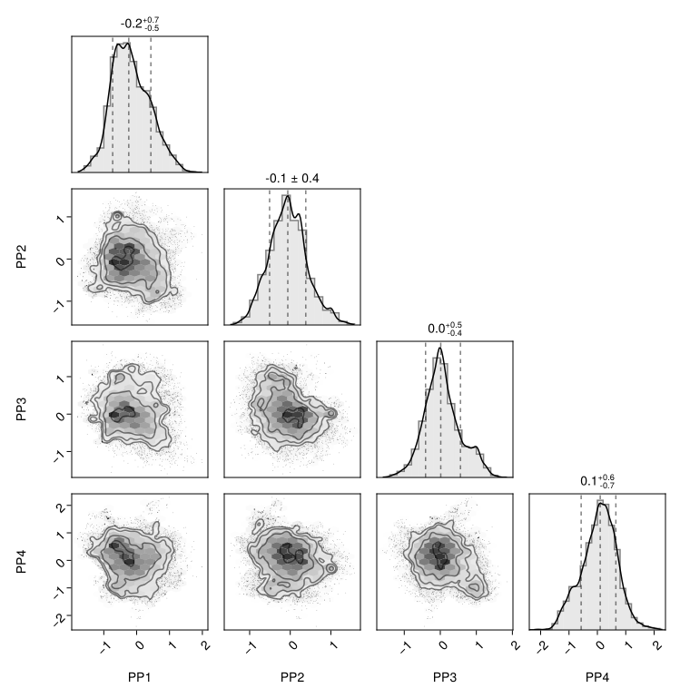

```julia
interp |> Sample(10000) |> values |> pairplot
```

#### 12.3.3.4 Postprocessing

In order to get the interpolated values in the original compositional space, we need to `revert` the preprocessing pipeline:

```julia
estim = revert(preproc, interp, cache)
```

110844 rows omitted

| 110854×5 GeoTable over 110854 view(::CartesianGrid, [76, 77, 78, 79, ..., 337107, 337109, 337193, 342719]) Cu Continuous [NoUnits] | 110854×5 GeoTable over 110854 view(::CartesianGrid, [76, 77, 78, 79, ..., 337107, 337109, 337193, 342719]) Au Continuous [NoUnits] | 110854×5 GeoTable over 110854 view(::CartesianGrid, [76, 77, 78, 79, ..., 337107, 337109, 337193, 342719]) Ag Continuous [NoUnits] | 110854×5 GeoTable over 110854 view(::CartesianGrid, [76, 77, 78, 79, ..., 337107, 337109, 337193, 342719]) S Continuous [NoUnits] | 110854×5 GeoTable over 110854 view(::CartesianGrid, [76, 77, 78, 79, ..., 337107, 337109, 337193, 342719]) geometry Hexahedron 🖈 Cartesian{NoDatum} |
| --- | --- | --- | --- | --- |
| 0.740818 | 3.2377e-5 | 0.000198158 | 0.258951 | Hexahedron((x: 724.995 m, y: -882.9 m, z: -399.92 m), ..., (x: 724.995 m, y: -857.9 m, z: -387.42 m)) |
| 0.742969 | 2.87321e-5 | 0.000198191 | 0.256804 | Hexahedron((x: 749.995 m, y: -882.9 m, z: -399.92 m), ..., (x: 749.995 m, y: -857.9 m, z: -387.42 m)) |
| 0.742919 | 2.87439e-5 | 0.000198253 | 0.256854 | Hexahedron((x: 774.995 m, y: -882.9 m, z: -399.92 m), ..., (x: 774.995 m, y: -857.9 m, z: -387.42 m)) |
| 0.742942 | 2.87977e-5 | 0.000198213 | 0.256831 | Hexahedron((x: 799.995 m, y: -882.9 m, z: -399.92 m), ..., (x: 799.995 m, y: -857.9 m, z: -387.42 m)) |
| 0.750764 | 3.60867e-5 | 0.000197071 | 0.249003 | Hexahedron((x: 824.995 m, y: -882.9 m, z: -399.92 m), ..., (x: 824.995 m, y: -857.9 m, z: -387.42 m)) |
| 0.740426 | 3.17599e-5 | 0.000203215 | 0.259339 | Hexahedron((x: 674.995 m, y: -857.9 m, z: -399.92 m), ..., (x: 674.995 m, y: -832.9 m, z: -387.42 m)) |
| 0.740843 | 3.23413e-5 | 0.000198197 | 0.258926 | Hexahedron((x: 699.995 m, y: -857.9 m, z: -399.92 m), ..., (x: 699.995 m, y: -832.9 m, z: -387.42 m)) |
| 0.740951 | 3.23215e-5 | 0.000198127 | 0.258818 | Hexahedron((x: 724.995 m, y: -857.9 m, z: -399.92 m), ..., (x: 724.995 m, y: -832.9 m, z: -387.42 m)) |
| 0.74297 | 2.87319e-5 | 0.00019819 | 0.256803 | Hexahedron((x: 749.995 m, y: -857.9 m, z: -399.92 m), ..., (x: 749.995 m, y: -832.9 m, z: -387.42 m)) |
| 0.74293 | 2.87491e-5 | 0.000198239 | 0.256843 | Hexahedron((x: 774.995 m, y: -857.9 m, z: -399.92 m), ..., (x: 774.995 m, y: -832.9 m, z: -387.42 m)) |
| ⋮ | ⋮ | ⋮ | ⋮ | ⋮ |

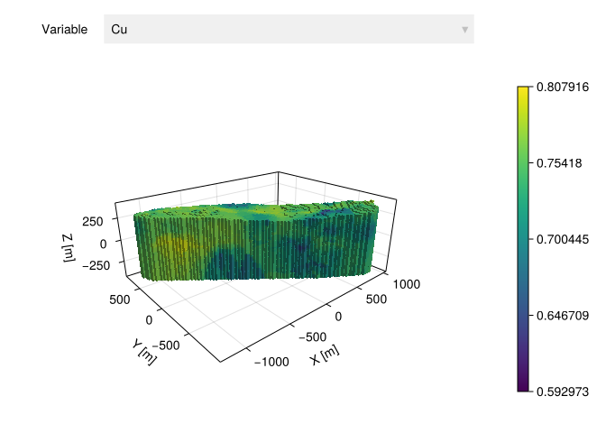

```julia
estim |> Select("Cu") |> viewer
```

### 12.3.4 Model of recovery

We introduce a simplistic model of metallurgical recovery using the grade of copper estimated at the mining blocks. We assume that the logistic function represents an ideal behavior for the recovery as the grade of copper increases:

```julia
μ = mean(estim.Cu) - 0.1
σ = std(estim.Cu)

f(Cu) = 1 / (1 + exp(-(Cu - μ) / σ))
```

```
f (generic function with 1 method)
```

```julia
recov = estim |> Map("Cu" => f => "f")
```

110844 rows omitted

| 110854×2 GeoTable over 110854 view(::CartesianGrid, [76, 77, 78, 79, ..., 337107, 337109, 337193, 342719]) f Continuous [NoUnits] | 110854×2 GeoTable over 110854 view(::CartesianGrid, [76, 77, 78, 79, ..., 337107, 337109, 337193, 342719]) geometry Hexahedron 🖈 Cartesian{NoDatum} |
| --- | --- |
| 0.991887 | Hexahedron((x: 724.995 m, y: -882.9 m, z: -399.92 m), ..., (x: 724.995 m, y: -857.9 m, z: -387.42 m)) |
| 0.992691 | Hexahedron((x: 749.995 m, y: -882.9 m, z: -399.92 m), ..., (x: 749.995 m, y: -857.9 m, z: -387.42 m)) |
| 0.992673 | Hexahedron((x: 774.995 m, y: -882.9 m, z: -399.92 m), ..., (x: 774.995 m, y: -857.9 m, z: -387.42 m)) |
| 0.992681 | Hexahedron((x: 799.995 m, y: -882.9 m, z: -399.92 m), ..., (x: 799.995 m, y: -857.9 m, z: -387.42 m)) |
| 0.994996 | Hexahedron((x: 824.995 m, y: -882.9 m, z: -399.92 m), ..., (x: 824.995 m, y: -857.9 m, z: -387.42 m)) |
| 0.991731 | Hexahedron((x: 674.995 m, y: -857.9 m, z: -399.92 m), ..., (x: 674.995 m, y: -832.9 m, z: -387.42 m)) |
| 0.991896 | Hexahedron((x: 699.995 m, y: -857.9 m, z: -399.92 m), ..., (x: 699.995 m, y: -832.9 m, z: -387.42 m)) |
| 0.991939 | Hexahedron((x: 724.995 m, y: -857.9 m, z: -399.92 m), ..., (x: 724.995 m, y: -832.9 m, z: -387.42 m)) |
| 0.992691 | Hexahedron((x: 749.995 m, y: -857.9 m, z: -399.92 m), ..., (x: 749.995 m, y: -832.9 m, z: -387.42 m)) |
| 0.992677 | Hexahedron((x: 774.995 m, y: -857.9 m, z: -399.92 m), ..., (x: 774.995 m, y: -832.9 m, z: -387.42 m)) |
| ⋮ | ⋮ |

Please check the paper by Hoffimann, Augusto, Resende, Mathias, Mazzinghy, Bianchetti, Mendes, Souza, Andrade, Tarcı́sio Domingues, et al. (2022) for a more elaborate model of metallurgical recovery in the locked-cycle-test.

### 12.3.5 Economic assessment

Given the grade of copper and metallurgical recovery for each block, we can proceed and apply the formula of economic value stated in our objectives:

```julia
ton = 1000u"kg"

ρ = 2.75 * ton / 1u"m^3"
P = 4000 / ton
Cₘ = 4 / ton
Cₚ = 10 / ton

model = @transform([estim recov],
  :value = volume(:geometry) * ρ * ((:Cu / 100) * :f * P - (Cₘ + Cₚ))
)
```

110844 rows omitted

| 110854×7 GeoTable over 110854 view(::CartesianGrid, [76, 77, 78, 79, ..., 337107, 337109, 337193, 342719]) Cu Continuous [NoUnits] | 110854×7 GeoTable over 110854 view(::CartesianGrid, [76, 77, 78, 79, ..., 337107, 337109, 337193, 342719]) Au Continuous [NoUnits] | 110854×7 GeoTable over 110854 view(::CartesianGrid, [76, 77, 78, 79, ..., 337107, 337109, 337193, 342719]) Ag Continuous [NoUnits] | 110854×7 GeoTable over 110854 view(::CartesianGrid, [76, 77, 78, 79, ..., 337107, 337109, 337193, 342719]) S Continuous [NoUnits] | 110854×7 GeoTable over 110854 view(::CartesianGrid, [76, 77, 78, 79, ..., 337107, 337109, 337193, 342719]) f Continuous [NoUnits] | 110854×7 GeoTable over 110854 view(::CartesianGrid, [76, 77, 78, 79, ..., 337107, 337109, 337193, 342719]) value Continuous [NoUnits] | 110854×7 GeoTable over 110854 view(::CartesianGrid, [76, 77, 78, 79, ..., 337107, 337109, 337193, 342719]) geometry Hexahedron 🖈 Cartesian{NoDatum} |
| --- | --- | --- | --- | --- | --- | --- |
| 0.740818 | 3.2377e-5 | 0.000198158 | 0.258951 | 0.991887 | 3.30694e5 | Hexahedron((x: 724.995 m, y: -882.9 m, z: -399.92 m), ..., (x: 724.995 m, y: -857.9 m, z: -387.42 m)) |
| 0.742969 | 2.87321e-5 | 0.000198191 | 0.256804 | 0.992691 | 3.33041e5 | Hexahedron((x: 749.995 m, y: -882.9 m, z: -399.92 m), ..., (x: 749.995 m, y: -857.9 m, z: -387.42 m)) |
| 0.742919 | 2.87439e-5 | 0.000198253 | 0.256854 | 0.992673 | 3.32986e5 | Hexahedron((x: 774.995 m, y: -882.9 m, z: -399.92 m), ..., (x: 774.995 m, y: -857.9 m, z: -387.42 m)) |
| 0.742942 | 2.87977e-5 | 0.000198213 | 0.256831 | 0.992681 | 3.33012e5 | Hexahedron((x: 799.995 m, y: -882.9 m, z: -399.92 m), ..., (x: 799.995 m, y: -857.9 m, z: -387.42 m)) |
| 0.750764 | 3.60867e-5 | 0.000197071 | 0.249003 | 0.994996 | 3.41178e5 | Hexahedron((x: 824.995 m, y: -882.9 m, z: -399.92 m), ..., (x: 824.995 m, y: -857.9 m, z: -387.42 m)) |
| 0.740426 | 3.17599e-5 | 0.000203215 | 0.259339 | 0.991731 | 330261.0 | Hexahedron((x: 674.995 m, y: -857.9 m, z: -399.92 m), ..., (x: 674.995 m, y: -832.9 m, z: -387.42 m)) |
| 0.740843 | 3.23413e-5 | 0.000198197 | 0.258926 | 0.991896 | 3.30721e5 | Hexahedron((x: 699.995 m, y: -857.9 m, z: -399.92 m), ..., (x: 699.995 m, y: -832.9 m, z: -387.42 m)) |
| 0.740951 | 3.23215e-5 | 0.000198127 | 0.258818 | 0.991939 | 3.30841e5 | Hexahedron((x: 724.995 m, y: -857.9 m, z: -399.92 m), ..., (x: 724.995 m, y: -832.9 m, z: -387.42 m)) |
| 0.74297 | 2.87319e-5 | 0.00019819 | 0.256803 | 0.992691 | 3.33042e5 | Hexahedron((x: 749.995 m, y: -857.9 m, z: -399.92 m), ..., (x: 749.995 m, y: -832.9 m, z: -387.42 m)) |
| 0.74293 | 2.87491e-5 | 0.000198239 | 0.256843 | 0.992677 | 3.32999e5 | Hexahedron((x: 774.995 m, y: -857.9 m, z: -399.92 m), ..., (x: 774.995 m, y: -832.9 m, z: -387.42 m)) |
| ⋮ | ⋮ | ⋮ | ⋮ | ⋮ | ⋮ | ⋮ |

**Tip**

The expression `[estim recov]` concatenates the columns of the two geotables assuming that they share the same geospatial domain. It is equivalent to `hcat(estim, recov)`.

We can then visualize all blocks with a positive economic value:

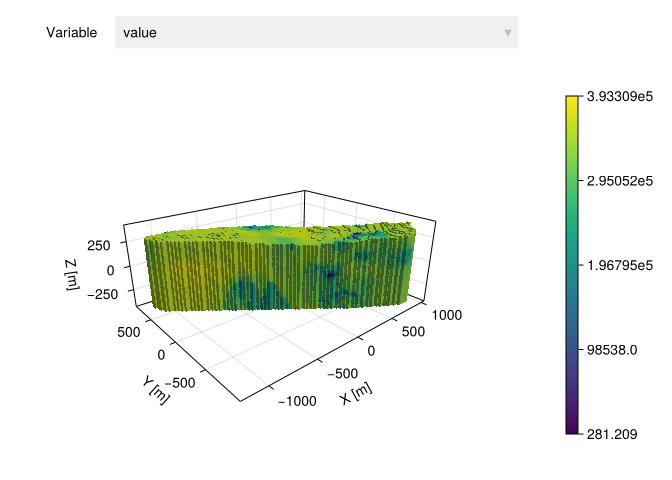

```julia
model |> Filter(x -> x.value > 0) |> Select("value") |> viewer
```

Or any criterion of interest such as positive economic value and small fraction of contaminants:

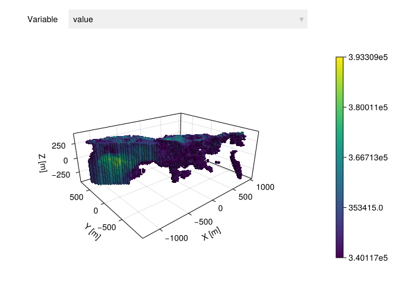

```julia
model |> Filter(x -> x.value > 0 && x.S < 0.25) |> Select("value") |> viewer
```

## 12.4 Summary

In this chapter, we illustrated an application of the framework in the mining industry. Among other things, we learned how to

- Perform simple economic assessment based on grades and metallurgical recoveries estimated at mining blocks using simple interpolation of transformed variables from drill hole samples.
- Use the tools covered in previous chapters to localize regions of interest in the mineral deposit.

Although the mathematical model presented here is simple, it is what most mining companies do. There is opportunity to improve these types of estimates with more sophisticated geospatial data science pipelines.

Aitchison, J. 1982. “The Statistical Analysis of Compositional Data.” *Journal of the Royal Statistical Society. Series B (Methodological)* 44 (2): 139–77. http://www.jstor.org/stable/2345821.

Friedman, Jerome H. 1987. “Exploratory Projection Pursuit.” *Journal of the American Statistical Association* 82 (397): 249–66. http://www.jstor.org/stable/2289161.

Hoffimann, Júlio, José Augusto, Lucas Resende, Marlon Mathias, Douglas Mazzinghy, Matheus Bianchetti, Mônica Mendes, Thiago Souza, Vitor Andrade, Tarcísio Domingues, et al. 2022. “GeoMet Dataset.” Zenodo, March. https://doi.org/10.5281/zenodo.7051975.

Hoffimann, Júlio, José Augusto, Lucas Resende, Marlon Mathias, Douglas Mazzinghy, Matheus Bianchetti, Mônica Mendes, Thiago Souza, Vitor Andrade, Tarcı́sio Domingues, et al. 2022. “Modeling Geospatial Uncertainty of Geometallurgical Variables with Bayesian Models and Hilbertkriging.” *Mathematical Geosciences* 54 (7): 1227–53. https://doi.org/10.1007/s11004-022-10013-1.